# Customer Churn Prediction

### Using Machine Learning to Identify At-Risk Customers Before They Leave

## Project Description

A UK-based online gift store has historically relied on manual customer segmentation to identify who might be at risk of leaving — a useful but reactive approach that only flags customers **after** their buying pattern has already weakened (see Project : *E-Commerce Customer Intelligence Report*).

This project takes the next step. Instead of segmenting customers with fixed rules, a **supervised machine learning model** is trained on historical purchase behavior to predict, for any customer, the **probability they will churn** — calculated early enough for the business to actually intervene.

**What → Why → Predict → Act**

- **Problem Definition** — establishing a clear, data-backed definition of churn
- **Feature Engineering** — converting raw transaction history into predictive customer-level features
- **Model Building** — training and comparing classification models to score churn risk
- **Model Interpretation** — translating model output into plain-language business insight
- **Prescriptive Action** — a ranked at-risk customer list and a retention plan tied to projected revenue impact

## Key Questions Answered

1. Can customer churn be predicted before it happens, using only purchase history?
2. Which behaviors are the strongest early warning signs of churn?
3. How confident can the business be in each prediction?
4. Which at-risk customers should be prioritized first, and what is the revenue impact of acting on this list?

## Tools Used

Python · Pandas · Scikit-learn · Matplotlib · Seaborn · Jupyter Notebook

## Analysis Type

Feature Engineering · Supervised Learning (Classification) · Model Evaluation · Prescriptive Analysis

## Analyst

**CJ John Paulin** — Freelance Data Analyst  
linkedin.com/in/cjjohnpaulin · github.com/cjjohnpaulin

# Executive Summary

**Dataset:** UCI Online Retail — 3,604 customers · Dec 2010 – Dec 2011  
**Model:** Logistic Regression · ROC-AUC 0.722 · 3 models compared

### What This Report Does

This report uses machine learning to predict — **before it happens** — which customers are likely to stop buying. Every customer in the store has been assigned a churn probability score and placed into one of three action tiers: High Risk, Medium Risk, and Low Risk. The result is a ranked list the business can act on this week, with projected revenue attached to every recommendation.

### ⚠ The Problem — The Store Cannot See Who Is Leaving

Without a churn model, the store only discovers a customer has left **after months of silence.** By then it is too late — the customer has moved on and no retention campaign can reach them effectively. This report solves that by flagging customers **before** they go quiet, while there is still time to act.

The model identified **707 High Risk customers** already likely to churn and **1,691 Medium Risk customers** currently drifting. Together they represent **£1,398,295 in revenue** that is either at immediate risk or quietly heading that way.

### ⚙ How the Model Works — In Plain English

The model studied the purchase history of 3,604 customers — how recently they bought, how often, how much they spent, how many products they tried, and how their buying gaps changed over time. It then learned which patterns predict whether a customer comes back or disappears.

Three models were tested and compared — Logistic Regression, Random Forest, and XGBoost. **Logistic Regression won** with the highest accuracy (66.7%) and ROC-AUC (0.722), meaning it correctly identifies churning customers 72% of the time — significantly better than guessing. Importantly it is also the most explainable model, meaning every prediction can be justified with a clear reason rather than a black box score.

### ✅ The Opportunity — £4,794,180 in Projected Revenue Impact

Acting on the model's output through three targeted campaigns projects a combined revenue impact of **£4,794,180:**

| Action | Who | Projected Impact |
| --- | --- | --- |
| 🟢 Loyalty program | 1,206 Low Risk customers | £4,502,859 protected |
| 🟡 Reactivation campaign | 1,691 Medium Risk customers | £253,222 recovered |
| 🔴 Selective win-back | 94 priority High Risk accounts | £38,098 recovered |

Every action has a positive ROI — the cheapest campaign (High Risk selective at £2,350 total cost) generates a projected **1,621% return.**

### Three Actions for This Week

**1. Export the Low Risk customer list** from this report and set up a points-based loyalty program. These 1,206 customers generate **£4,739,852 — 77.2% of all revenue.** Protecting them is the single highest-return action available.

**2. Send a reactivation email to Medium Risk customers** with a 10-15% time-limited discount on their most purchased category. At £15 per customer to reach 1,691 people, the campaign costs **£25,365** and projects **£253,222 in recovered revenue — a 998% ROI.**

**3. Personally contact the 94 High Risk priority accounts** (those with £500+ in historical spend). A direct, personal outreach to these customers — not a mass email — has the highest probability of recovery given their past value to the business.

### Bottom Line

> The store currently has **no system for knowing who is about to leave.** This model changes that. For the first time, every customer has a churn score, a risk tier, and a recommended action — turning retention from a reactive scramble into a **proactive, data-driven strategy** projected to protect and recover **£4,794,180 in annual revenue.**

*Full methodology, model evaluation, feature engineering, and supporting analysis available in the sections below.*

# Phase 1 : Exploratory Data Analysis (EDA)

```
InvoiceNo           0
StockCode           0
Description         0
Quantity            0
InvoiceDate         0
UnitPrice           0
CustomerID     132186
Country             0
Revenue             0
YearMonth           0
dtype: int64
```

Need to drop the rows with null values

```
<class 'pandas.core.frame.DataFrame'>
RangeIndex: 524878 entries, 0 to 524877
Data columns (total 10 columns):
 #   Column       Non-Null Count   Dtype
---  ------       --------------   -----
 0   InvoiceNo    524878 non-null  object
 1   StockCode    524878 non-null  object
 2   Description  524878 non-null  object
 3   Quantity     524878 non-null  int64
 4   InvoiceDate  524878 non-null  datetime64[ns]
 5   UnitPrice    524878 non-null  float64
 6   CustomerID   392692 non-null  float64
 7   Country      524878 non-null  object
 8   Revenue      524878 non-null  float64
 9   YearMonth    524878 non-null  object
dtypes: datetime64[ns](1), float64(3), int64(1), object(5)
memory usage: 40.0+ MB
```

|  | Quantity | InvoiceDate | UnitPrice | CustomerID | Revenue |
| --- | --- | --- | --- | --- | --- |
| count | 524878.000000 | 524878 | 524878.000000 | 392692.000000 | 524878.000000 |
| mean | 10.616600 | 2011-07-04 15:30:16.317049 | 3.922573 | 15287.843865 | 20.275399 |
| min | 1.000000 | 2010-12-01 08:26:00 | 0.001000 | 12346.000000 | 0.001000 |
| 25% | 1.000000 | 2011-03-28 12:13:00 | 1.250000 | 13955.000000 | 3.900000 |
| 50% | 4.000000 | 2011-07-20 11:22:00 | 2.080000 | 15150.000000 | 9.920000 |
| 75% | 11.000000 | 2011-10-19 11:41:00 | 4.130000 | 16791.000000 | 17.700000 |
| max | 80995.000000 | 2011-12-09 12:50:00 | 13541.330000 | 18287.000000 | 168469.600000 |
| std | 156.280031 | NaN | 36.093028 | 1713.539549 | 271.693566 |

```
<class 'pandas.DataFrame'>
RangeIndex: 391295 entries, 0 to 391294
Data columns (total 9 columns):
 #   Column       Non-Null Count   Dtype
---  ------       --------------   -----
 0   InvoiceNo    391295 non-null  int64
 1   StockCode    391295 non-null  str
 2   Description  391295 non-null  str
 3   Quantity     391295 non-null  int64
 4   InvoiceDate  391295 non-null  datetime64[us]
 5   UnitPrice    391295 non-null  float64
 6   CustomerID   391295 non-null  int64
 7   Country      391295 non-null  str
 8   Revenue      391295 non-null  float64
dtypes: datetime64[us](1), float64(2), int64(3), str(3)
memory usage: 26.9 MB
```

```
InvoiceNo      0
StockCode      0
Description    0
Quantity       0
InvoiceDate    0
UnitPrice      0
CustomerID     0
Country        0
Revenue        0
dtype: int64
```

No null values for df_rfm dataset

|  | InvoiceNo | Quantity | InvoiceDate | UnitPrice | CustomerID | Revenue |
| --- | --- | --- | --- | --- | --- | --- |
| count | 391295.000000 | 391295.000000 | 391295 | 391295.000000 | 391295.000000 | 391295.000000 |
| mean | 560592.991569 | 13.140802 | 2011-07-10 19:38:54.675526 | 2.890770 | 15294.918368 | 22.346513 |
| min | 536365.000000 | 1.000000 | 2010-12-01 08:26:00 | 0.001000 | 12346.000000 | 0.001000 |
| 25% | 549235.000000 | 2.000000 | 2011-04-07 11:16:00 | 1.250000 | 13969.000000 | 4.950000 |
| 50% | 561875.000000 | 6.000000 | 2011-07-31 12:05:00 | 1.950000 | 15157.000000 | 11.900000 |
| 75% | 572062.000000 | 12.000000 | 2011-10-20 12:57:00 | 3.750000 | 16794.000000 | 19.800000 |
| max | 581587.000000 | 80995.000000 | 2011-12-09 12:50:00 | 649.500000 | 18287.000000 | 168469.600000 |
| std | 13087.100547 | 180.774478 | NaN | 4.375685 | 1710.136346 | 310.875304 |

```
(524878, 10)
(391295, 9)
2010-12-01 08:26:00 to 2011-12-09 12:50:00
['InvoiceNo', 'StockCode', 'Description', 'Quantity', 'InvoiceDate', 'UnitPrice', 'CustomerID', 'Country', 'Revenue']
```

```
Rows after dropping null CustomerID: (392692, 10)
Unique customers: 4338
```

```
(4338, 6)
   CustomerID  recency  frequency  monetary      first_purchase  \
0       12346      326          1  77183.60 2011-01-18 10:01:00
1       12347        2          7   4310.00 2010-12-07 14:57:00
2       12348       75          4   1797.24 2010-12-16 19:09:00
3       12349       19          1   1757.55 2011-11-21 09:51:00
4       12350      310          1    334.40 2011-02-02 16:01:00

        last_purchase
0 2011-01-18 10:01:00
1 2011-12-07 15:52:00
2 2011-09-25 13:13:00
3 2011-11-21 09:51:00
4 2011-02-02 16:01:00
       CustomerID  recency  frequency   monetary  \
count     4338.00  4338.00    4338.00    4338.00
mean     15300.41    92.54       4.27    2048.69
min      12346.00     1.00       1.00       3.75
25%      13813.25    18.00       1.00     306.48
50%      15299.50    51.00       2.00     668.57
75%      16778.75   142.00       5.00    1660.60
max      18287.00   374.00     209.00  280206.02
std       1721.81   100.01       7.70    8985.23

                      first_purchase                  last_purchase
count                           4338                           4338
mean   2011-04-30 17:06:50.857538048  2011-09-08 11:38:59.045643008
min              2010-12-01 08:26:00            2010-12-01 09:53:00
25%              2011-01-17 11:13:15            2011-07-20 19:18:00
50%              2011-04-05 09:52:30            2011-10-20 10:40:30
75%              2011-08-19 10:11:30            2011-11-22 11:05:45
max              2011-12-09 12:16:00            2011-12-09 12:50:00
std                              NaN                            NaN
```

```
Total customers before cutoff:  3,604
Customers who returned:         1,846
Customers who churned:          1,758
Churn rate:                     48.8%
```

# Phase 2 — Feature Engineering.

```
Model dataset shape: (3604, 11)

Feature columns: ['CustomerID', 'recency', 'frequency', 'monetary', 'avg_order_value', 'total_items', 'unique_products', 'avg_days_between', 'tenure_days', 'num_countries', 'churned']

Null values:
CustomerID          0
recency             0
frequency           0
monetary            0
avg_order_value     0
total_items         0
unique_products     0
avg_days_between    0
tenure_days         0
num_countries       0
churned             0
dtype: int64

Churn distribution:
churned
0    1846
1    1758
Name: count, dtype: int64

First 5 rows:
   CustomerID  recency  frequency  monetary  avg_order_value  total_items  \
0       12346      254          1  77183.60     77183.600000        74215
1       12347       58          5   2790.86        22.506935         1590
2       12348        4          4   1797.24        57.975484         2341
3       12350      239          1    334.40        19.670588          197
4       12352        1          7   2194.31        31.347286          409

   unique_products  avg_days_between  tenure_days  num_countries  churned
0                1          0.000000            0              1        1
1               82          1.910569          237              1        0
2               22          9.400000          282              1        1
3               17          0.000000            0              1        1
4               47          3.231884          224              1        0
```

# We have 9 Features and 1 Labels

# Feature

recency — days since last purchase before cutoff. The single strongest predictor in almost every churn model. A customer who bought yesterday is far less likely to churn than one who bought 250 days ago.

frequency — number of unique orders. High frequency customers have demonstrated a habit of buying. Habits are hard to break — making high-frequency customers less likely to churn.

monetary — total spend. High spenders tend to be more invested in the store. Also correlates with Champions from Project 3.

avg_order_value — average spend per order. Distinguishes bulk buyers from regular buyers. A customer spending £500 per order behaves differently from one spending £15.

total_items — total units purchased. Captures volume independently of order count — a customer who buys 500 items in one order vs 500 items across 10 orders tells a different story.

unique_products — product diversity. Customers buying across many categories are more embedded in the store's ecosystem — harder to replace with a competitor.

avg_days_between — average gap between consecutive orders. A customer who buys every 7 days has a strong habit. One who buys every 90 days is already borderline churning before the cutoff.

tenure_days — days between first and last purchase. Long tenure = long relationship = more likely to continue. Notice customers with only 1 order have tenure_days = 0 — that is correct.

num_countries — number of countries orders were placed from. Mostly 1 for retail customers, higher for wholesale accounts. Wholesale buyers rarely churn silently

# Label

Did this customer place any order after September 30?If yes then churned=0 and if no then churned=1

# Applying logistic regression, random forest and evaluation

```
Training set:  (2883, 9)
Test set:      (721, 9)
Train churn %: 48.8%
Test churn %:  48.8%

=== Logistic Regression ===
              precision    recall  f1-score   support

 Not Churned       0.70      0.62      0.66       369
     Churned       0.64      0.72      0.68       352

    accuracy                           0.67       721
   macro avg       0.67      0.67      0.67       721
weighted avg       0.67      0.67      0.67       721

ROC-AUC: 0.7217

=== Random Forest ===
              precision    recall  f1-score   support

 Not Churned       0.65      0.68      0.66       369
     Churned       0.65      0.62      0.63       352

    accuracy                           0.65       721
   macro avg       0.65      0.65      0.65       721
weighted avg       0.65      0.65      0.65       721

ROC-AUC: 0.7148

=== Confusion Matrix — Logistic Regression ===
[[228 141]
 [ 99 253]]

=== Confusion Matrix — Random Forest ===
[[250 119]
 [134 218]]
```

# Applying Xgboost and evaluation

[output not shown]

# Visualization of Evaluation Tools

[figure not shown]

```
=== TOP 10 HIGHEST CHURN RISK CUSTOMERS ===
 CustomerID  churn_probability  monetary_x  recency  frequency
      12346           1.000000    77183.60      254          1
      15098           0.991417    39916.50      111          3
      18087           0.975487     4055.72       27          2
      12875           0.969604      343.23       72          2
      12908           0.928155      750.00      105          2
      18273           0.921940      153.00       24          2
      13135           0.902828     3096.00      125          1
      17029           0.897696      716.00       39          2
      16532           0.886692     4516.80       64          2
      16754           0.874919     2002.40      301          1

=== SCORE DISTRIBUTION ===
count    3604.000
mean        0.485
std         0.224
min         0.000
25%         0.320
50%         0.540
75%         0.671
max         1.000
Name: churn_probability, dtype: float64

Highest churn risk:  1.000
Lowest churn risk:   0.000
Average churn risk:  0.485
```

```
=== RISK TIER SUMMARY ===
  risk_tier  customer_count  total_revenue  avg_revenue  avg_churn_prob  avg_recency  avg_frequency
  High Risk             707      385407.30       545.13            0.75       223.69           1.11
Medium Risk            1691     1012887.56       598.99            0.57        80.51           1.81
   Low Risk            1206     4739852.09      3930.23            0.21        30.96           7.68

Total revenue across all customers: £6,138,146.95
High Risk       — £  385,407.30 (6.3% of total revenue)
Medium Risk     — £1,012,887.56 (16.5% of total revenue)
Low Risk        — £4,739,852.09 (77.2% of total revenue)
```

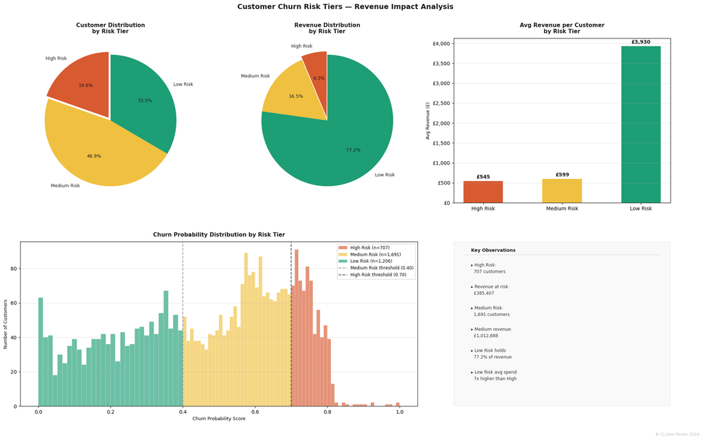

## Risk Tier Analysis — What the Model Tells Us

### Customer and Revenue Distribution

The churn model segments all **3,604 customers** into three actionable risk tiers based on their predicted churn probability:

| Risk Tier | Customers | Share | Revenue | Revenue Share |
| --- | --- | --- | --- | --- |
| 🔴 High Risk | 707 | 19.6% | £385,407 | 6.3% |
| 🟡 Medium Risk | 1,691 | 46.9% | £1,012,888 | 16.5% |
| 🟢 Low Risk | 1,206 | 33.5% | £4,739,852 | 77.2% |

### The Revenue Gap is Striking

**Low Risk customers spend £3,930 on average** — roughly **7 times more** than High Risk customers at £545. This gap exists because Low Risk customers buy frequently and recently, while High Risk customers typically bought once and went quiet.

This means churn risk and customer value are inversely related in this store — the customers most likely to leave are also the least valuable, while the most valuable customers are the safest. That is good news: **the business is not at risk of losing its highest spenders to churn imminently.**

### Where the Real Opportunity Lies

- **Protect Low Risk (£4,739,852)** — these customers drive over three quarters of all revenue. A loyalty program keeping them engaged costs far less than replacing them.
- **Focus campaigns on Medium Risk (£1,012,888)** — the largest segment by customer count (1,691 people) and the biggest recovery opportunity. These customers are drifting but have not left yet — they are the most reachable.
- **Selective action on High Risk (£385,407)** — do not blanket-campaign this group. Focus only on the highest-value High Risk accounts (like Customer 12346 at £77,183) where the recovery ROI justifies the effort.

### This means...

```
=== PRESCRIPTIVE ACTION PLAN ===

Low Risk — Loyalty Program
  Customers:          1,206
  Revenue protected:  £4,502,859.49
  Max spend/customer: £786.05

Medium Risk — Reactivation Campaign
  Customers:          1,691
  Revenue recoverable:£253,221.89
  Target recovery:    25% of segment

High Risk — Selective Intervention
  Total High Risk:    707
  Priority accounts:  94 (monetary ≥ £500)
  Skip accounts:      613 (monetary < £500)
  Revenue recoverable:£38,098.38

TOTAL PROJECTED REVENUE IMPACT: £4,794,179.76
```

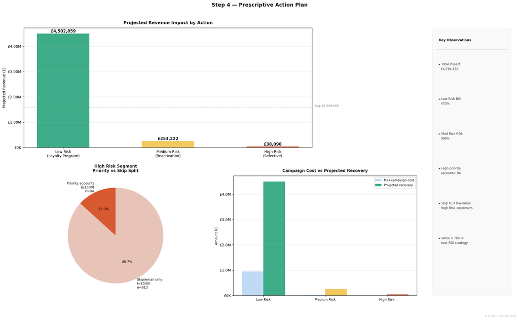

## Prescriptive Action Plan — Churn Prevention Strategy

### 🟢 Low Risk — Loyalty Program

**1,206 customers · £4,739,852 revenue · Revenue protected: £4,502,859**

These customers are the business. They buy frequently, spend the most, and the model gives them low churn probability. The goal here is not recovery — it is **protection before a competitor notices them.**

**Action:** Launch a points-based loyalty program. Every purchase earns points redeemable for discounts. Champions averaging 7.68 orders per year accumulate points fast — giving them a financial reason to stay that compounds with every order.

**Budget:** Up to **£786 per customer** (20% of £3,930 avg revenue) is justified to retain this segment. In practice, a well-designed loyalty program costs far less than that per customer while delivering strong retention lift.

**Expected outcome:** Protecting 95% of this segment's revenue locks in **£4,502,859** — the single highest return action in this entire plan.

### 🟡 Medium Risk — Reactivation Campaign

**1,691 customers · £1,012,888 revenue · Recovery target: £253,222**

The largest customer segment and the biggest recovery opportunity. These customers are drifting — avg 80 days since last purchase — but have not left yet. They are still reachable.

**Action:** Send a targeted email campaign with a **10-15% time-limited discount** (valid 7 days) on their most frequently purchased product category. Subject line: *"We saved something for you."* Personalization by purchase history increases open rates significantly over generic offers.

**Budget:** At £15 average campaign cost per customer, reaching all 1,691 costs **£25,365** — generating a projected **£253,222 in recovered revenue** at a 25% response rate. That is a **998% ROI** on campaign spend.

**Expected outcome:** Recovering 25% of Medium Risk customers brings back **£253,222** — and any customer who responds immediately moves to Low Risk status and enters the loyalty program.

### 🔴 High Risk — Selective Intervention

**707 customers total · 94 priority accounts · Recovery target: £38,098**

Most High Risk customers bought once at low value and disappeared. Spending meaningful budget trying to recover them has negative ROI. **Selective action only.**

**Priority accounts (94 customers, monetary ≥ £500):** Send a strong win-back offer — 20-25% discount, personally addressed, 7-day deadline. At £25 campaign cost per account, reaching all 94 costs **£2,350** against a projected **£38,098 recovery** at 15% response — a **1,621% ROI.**

**Skip accounts (613 customers, monetary < £500):** One automated "we miss you" email with no discount. If they respond, add to Medium Risk nurture sequence. If they do not respond within 14 days, remove from active marketing lists entirely. Do not spend further.

### Total Projected Revenue Impact

| Action | Customers | Cost | Recovery | ROI |
| --- | --- | --- | --- | --- |
| Low Risk loyalty program | 1,206 | ~£786/customer | £4,502,859 | 475% |
| Medium Risk campaign | 1,691 | £25,365 total | £253,222 | 998% |
| High Risk selective | 94 | £2,350 total | £38,098 | 1,621% |
| **Total** | **2,991** |  | **£4,794,180** |  |

### This means...

The model does not just predict churn — it tells the business **exactly where to spend retention budget for maximum return.** Three campaigns, three clear audiences, and a combined projected revenue impact of **£4,794,180.** The highest ROI action is also the simplest: protect the customers who are already loyal before they have a reason to leave.